# Classification Project

Machine Learning 2

Aleksandra Jendrusiak, Weronika Motkowska

The aim of the project is to forecast whether there will be rain tomorrow in Australia. Weather forecasting is a part of our everyday life and especially rainfall and other precipitation might influence our plans for the next day. The data is available on Kaggle.com.

First, we install all necessary packages.

```r
# install.packages("tidyverse")
# install.packages("tidygeocoder")
# install.packages("lubridate")
# install.packages("hydroTSM")
# install.packages("mltools") # one_hot (replace by caret?)
# install.packages("ozmaps")
# install.packages("tree")
# install.packages("rpart")
# install.packages("rpart.plot")
# install.packages("rattle")
# install.packages("here")
# install.packages("caret")
# install.packages("randomForest")
# install.pacages("gbm")
```

Next, we load them into memory.

```r
library(dplyr)
library(ggplot2)
library(data.table)
library(ggpubr)
library(tidyverse)
library(tidygeocoder)
library(lubridate)
library(hydroTSM)
library(mltools)
library(ozmaps)
library(tree)
library(caret)
library(rpart)
library(rpart.plot)
library(rattle)
library(pROC)
library(here)
library(randomForest)
library(gbm)
```

# 1 Data loading

```r
data <- read.csv(here("data", "weatherAUS.csv")) %>% as.data.frame()
glimpse(data)
```

```
## Rows: 145,460
## Columns: 23
## $ Date          <chr> "2008-12-01", "2008-12-02", "2008-12-03", "2008-12-04", ~
## $ Location      <chr> "Albury", "Albury", "Albury", "Albury", "Albury", "Albur~
## $ MinTemp       <dbl> 13.4, 7.4, 12.9, 9.2, 17.5, 14.6, 14.3, 7.7, 9.7, 13.1, ~
## $ MaxTemp       <dbl> 22.9, 25.1, 25.7, 28.0, 32.3, 29.7, 25.0, 26.7, 31.9, 30~
## $ Rainfall      <dbl> 0.6, 0.0, 0.0, 0.0, 1.0, 0.2, 0.0, 0.0, 0.0, 1.4, 0.0, 2~
## $ Evaporation   <dbl> NA, NA, NA, NA, NA, NA, NA, NA, NA, NA, NA, NA, NA, NA, ~
## $ Sunshine      <dbl> NA, NA, NA, NA, NA, NA, NA, NA, NA, NA, NA, NA, NA, NA, ~
## $ WindGustDir   <chr> "W", "WNW", "WSW", "NE", "W", "WNW", "W", "W", "NNW", "W~
## $ WindGustSpeed <int> 44, 44, 46, 24, 41, 56, 50, 35, 80, 28, 30, 31, 61, 44, ~
## $ WindDir9am    <chr> "W", "NNW", "W", "SE", "ENE", "W", "SW", "SSE", "SE", "S~
## $ WindDir3pm    <chr> "WNW", "WSW", "WSW", "E", "NW", "W", "W", "W", "NW", "SS~
## $ WindSpeed9am  <int> 20, 4, 19, 11, 7, 19, 20, 6, 7, 15, 17, 15, 28, 24, 4, N~
## $ WindSpeed3pm  <int> 24, 22, 26, 9, 20, 24, 24, 17, 28, 11, 6, 13, 28, 20, 30~
## $ Humidity9am   <int> 71, 44, 38, 45, 82, 55, 49, 48, 42, 58, 48, 89, 76, 65, ~
## $ Humidity3pm   <int> 22, 25, 30, 16, 33, 23, 19, 19, 9, 27, 22, 91, 93, 43, 3~
## $ Pressure9am   <dbl> 1007.7, 1010.6, 1007.6, 1017.6, 1010.8, 1009.2, 1009.6, ~
## $ Pressure3pm   <dbl> 1007.1, 1007.8, 1008.7, 1012.8, 1006.0, 1005.4, 1008.2, ~
## $ Cloud9am      <int> 8, NA, NA, NA, 7, NA, 1, NA, NA, NA, NA, 8, 8, NA, NA, 0~
## $ Cloud3pm      <int> NA, NA, 2, NA, 8, NA, NA, NA, NA, NA, NA, 8, 8, 7, NA, N~
## $ Temp9am       <dbl> 16.9, 17.2, 21.0, 18.1, 17.8, 20.6, 18.1, 16.3, 18.3, 20~
## $ Temp3pm       <dbl> 21.8, 24.3, 23.2, 26.5, 29.7, 28.9, 24.6, 25.5, 30.2, 28~
## $ RainToday     <chr> "No", "No", "No", "No", "No", "No", "No", "No", "No", "Y~
## $ RainTomorrow  <chr> "No", "No", "No", "No", "No", "No", "No", "No", "Yes", "~
```

```r
summary(data)
```

```
##      Date             Location            MinTemp         MaxTemp
##  Length:145460      Length:145460      Min.   :-8.50   Min.   :-4.80
##  Class :character   Class :character   1st Qu.: 7.60   1st Qu.:17.90
##  Mode  :character   Mode  :character   Median :12.00   Median :22.60
##                                        Mean   :12.19   Mean   :23.22
##                                        3rd Qu.:16.90   3rd Qu.:28.20
##                                        Max.   :33.90   Max.   :48.10
##                                        NA's   :1485    NA's   :1261
##     Rainfall        Evaporation        Sunshine     WindGustDir
##  Min.   :  0.000   Min.   :  0.00   Min.   : 0.00   Length:145460
##  1st Qu.:  0.000   1st Qu.:  2.60   1st Qu.: 4.80   Class :character
##  Median :  0.000   Median :  4.80   Median : 8.40   Mode  :character
##  Mean   :  2.361   Mean   :  5.47   Mean   : 7.61
##  3rd Qu.:  0.800   3rd Qu.:  7.40   3rd Qu.:10.60
##  Max.   :371.000   Max.   :145.00   Max.   :14.50
##  NA's   :3261      NA's   :62790    NA's   :69835
##  WindGustSpeed     WindDir9am         WindDir3pm         WindSpeed9am
##  Min.   :  6.00   Length:145460      Length:145460      Min.   :  0.00
##  1st Qu.: 31.00   Class :character   Class :character   1st Qu.:  7.00
##  Median : 39.00   Mode  :character   Mode  :character   Median : 13.00
##  Mean   : 40.03                                         Mean   : 14.04
##  3rd Qu.: 48.00                                         3rd Qu.: 19.00
##  Max.   :135.00                                         Max.   :130.00
##  NA's   :10263                                          NA's   :1767
##   WindSpeed3pm    Humidity9am      Humidity3pm      Pressure9am
##  Min.   : 0.00   Min.   :  0.00   Min.   :  0.00   Min.   : 980.5
##  1st Qu.:13.00   1st Qu.: 57.00   1st Qu.: 37.00   1st Qu.:1012.9
##  Median :19.00   Median : 70.00   Median : 52.00   Median :1017.6
##  Mean   :18.66   Mean   : 68.88   Mean   : 51.54   Mean   :1017.6
##  3rd Qu.:24.00   3rd Qu.: 83.00   3rd Qu.: 66.00   3rd Qu.:1022.4
##  Max.   :87.00   Max.   :100.00   Max.   :100.00   Max.   :1041.0
##  NA's   :3062    NA's   :2654     NA's   :4507     NA's   :15065
##   Pressure3pm        Cloud9am        Cloud3pm        Temp9am
##  Min.   : 977.1   Min.   :0.00    Min.   :0.00    Min.   :-7.20
##  1st Qu.:1010.4   1st Qu.:1.00    1st Qu.:2.00    1st Qu.:12.30
##  Median :1015.2   Median :5.00    Median :5.00    Median :16.70
##  Mean   :1015.3   Mean   :4.45    Mean   :4.51    Mean   :16.99
##  3rd Qu.:1020.0   3rd Qu.:7.00    3rd Qu.:7.00    3rd Qu.:21.60
##  Max.   :1039.6   Max.   :9.00    Max.   :9.00    Max.   :40.20
##  NA's   :15028    NA's   :55888   NA's   :59358   NA's   :1767
##     Temp3pm       RainToday         RainTomorrow
##  Min.   :-5.40   Length:145460      Length:145460
##  1st Qu.:16.60   Class :character   Class :character
##  Median :21.10   Mode  :character   Mode  :character
##  Mean   :21.68
##  3rd Qu.:26.40
##  Max.   :46.70
##  NA's   :3609
```

# 2 Data visualization

First, we can create the bar plot of the *target variable* which is *RainTomorrow*.

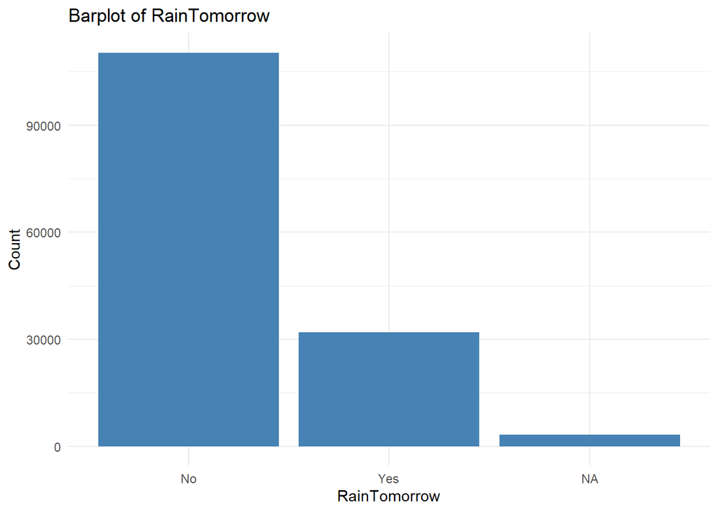

```r
ggplot(data = data, aes(x = factor(RainTomorrow))) +
  geom_bar(stat = "count", fill = "steelblue") +
  labs(title = "Barplot of RainTomorrow",
         x = "RainTomorrow", y = "Count") +
  theme_minimal()
```

Now we can also visualize the explanatory variables. First we create barplots for discrete variables.

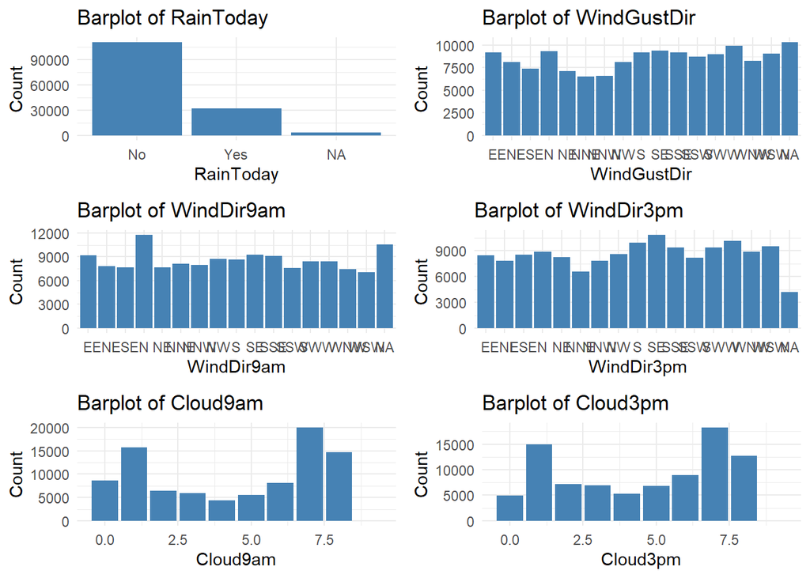

```r
discrete <- c("RainToday", "WindGustDir", "WindDir9am", "WindDir3pm", "Cloud9am", "Cloud3pm")

plots_dicrete <- lapply(
              discrete,
              function(variable) {
                x <- ggplot(data, aes(x = eval(parse(text = variable)))) +
                         geom_bar(stat = "count", fill = "steelblue") +
                  labs(title = paste("Barplot of", variable),
                       x = variable, y = "Count") +
                  theme_minimal()
              }
)

allplots <- ggarrange(plotlist = plots_dicrete,
                      ncol = 2, nrow = 3)

allplots
```

Now we create histograms of continuous varibles.

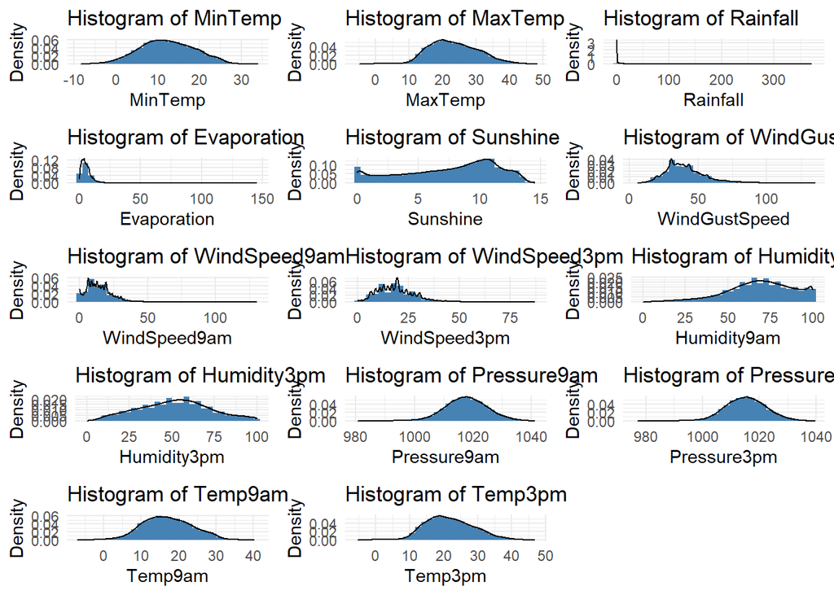

```r
continuous <- colnames(data %>% select(-c(all_of(discrete), "Date", "Location", "RainTomorrow")))

plots_continuous <- lapply(
              continuous,
              function(variable) {
                x <- ggplot(data, aes(x = eval(parse(text = variable)))) +
                         geom_histogram(aes(y = ..density..),  fill = "steelblue") +
                  labs(title = paste("Histogram of", variable),
                       x = variable, y = "Density") +
                  geom_density() +
                  theme_minimal()
              }
)

allplots <- ggarrange(plotlist = plots_continuous,
                      ncol = 3, nrow = 5)

allplots
```

# 3 Data transformation

First, we need to transform the *target variable* into binary number.

```r
data$RainTomorrow <- ifelse(data$RainTomorrow == "Yes", 1, 0)
```

Some of the varibles such like *Rainfall* or *Location* might bring some information about the target variable, but might not be useful in a straightfroward way (the distribution is skewed and with many outliers), so we will transform them. We will also transform the *Location* into *Latitude* and *Longitude* and extract some infromation from the *Date* variable.

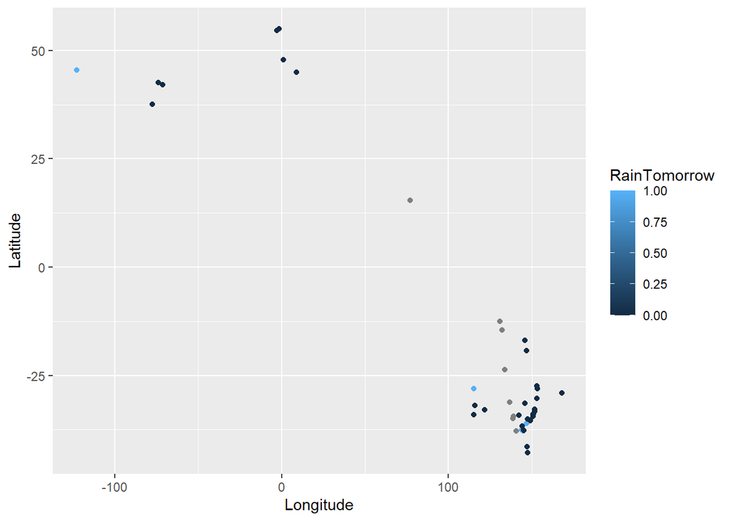

```r
data$RainfallBin <- ifelse(data$Rainfall > 0, 1, 0)
data$RainfallLog <- log(data$Rainfall + 1)

# capping using inter quantile range
Rainfall.Q25 <- quantile(data$Rainfall, 0.25, na.rm = TRUE)
Rainfall.Q75 <- quantile(data$Rainfall, 0.75, na.rm = TRUE)
Rainfall.IQR <-  Rainfall.Q75 - Rainfall.Q25
data$RainfallCap <- data$Rainfall
data$RainfallCap[which(data$RainfallCap > Rainfall.Q75 + 3 * Rainfall.IQR)] <- Rainfall.Q75 + 3 * Rainfall.IQR

data$EvaporationBin <- ifelse(data$Evaporation > 0, 1, 0)
data$EvaporationLog <- log(data$Evaporation + 1)

# capping using inter quantile range
Evaporation.Q25 <- quantile(data$Evaporation, 0.25, na.rm = TRUE)
Evaporation.Q75 <- quantile(data$Evaporation, 0.75, na.rm = TRUE)
Evaporation.IQR <-  Evaporation.Q75 - Evaporation.Q25
data$EvaporationCap <- data$Evaporation
data$EvaporationCap[which(data$EvaporationCap > Evaporation.Q75 + 3 * Evaporation.IQR)] <- Evaporation.Q75 + 3 * Evaporation.IQR

data$RainToday <- ifelse(data$RainToday == "Yes", 1, 0)

# converting Location into Lon gitude and Latitude
data$Location <- gsub("([a-z])([A-Z])", "\\1 \\2", data$Location)
data <- geocode(data, city = Location, method = "osm") %>%
  rename("Latitude" = "lat", "Longitude" = "long")
ggplot(data, aes(x = Longitude, y = Latitude, color = RainTomorrow)) + geom_point()
```

```r
# extracting information from Date
data$Date <- as.Date(data$Date, "%Y-%m-%d")
data$Season <- time2season(data$Date, out.fmt = "seasons")
# data$Year <- year(data$Date)
# data$Month <- month(data$Date)
# data$Day <- day(data$Date)

# reducing the wind directions (from 16 to 8)
for (var in c("WindGustDir", "WindDir9am", "WindDir3pm")){
  data[, var] <- substr(data[, var][[1]], 1, 2)
}

continuous <- c(continuous, "RainfallLog", "EvaporationLog", "RainfallCap", "EvaporationCap", "Longitude", "Latitude")
discrete <- c(discrete, "RainfallBin", "EvaporationBin", "Season", "Location")
```

Now, we will split the data into the train and test set.

```r
data <- data[!is.na(data$RainTomorrow), ] # removing NAs in target variable

set.seed(123456789)
training_obs <- createDataPartition(data$RainTomorrow,
                                    p = 0.7,
                                    list = FALSE)

data.train <- data[training_obs, ] %>% as.data.frame()
data.test  <- data[-training_obs, ] %>% as.data.frame()
```

# 4 Correlation analysis

Now we can analyze the correlation between variables.

```r
numeric.train <- data.train[, c(continuous, "RainTomorrow", "RainToday", "EvaporationBin", "RainfallBin")]

data.train.cor.pearson = cor(na.omit(numeric.train), method = "pearson")
data.train.cor.pearson[, "RainTomorrow"] %>% sort()
```

```
##       Sunshine    Pressure9am    Pressure3pm        Temp3pm        MaxTemp
##    -0.44586985    -0.27742374    -0.25618013    -0.18847976    -0.15228399
## EvaporationLog EvaporationCap    Evaporation      Longitude        Temp9am
##    -0.13309477    -0.13225907    -0.12807479    -0.03518653    -0.02150297
## EvaporationBin       Latitude        MinTemp   WindSpeed9am   WindSpeed3pm
##    -0.01913274     0.02062745     0.08254679     0.08515759     0.09945944
##  WindGustSpeed    Humidity9am       Rainfall    RainfallBin      RainToday
##     0.24085632     0.25558262     0.25638007     0.29796473     0.31077725
##    RainfallCap    RainfallLog    Humidity3pm   RainTomorrow
##     0.33467266     0.34238447     0.45072943     1.00000000
```

```r
data.train.cor.spearman = cor(na.omit(numeric.train), method = "spearman")
data.train.cor.spearman[, "RainTomorrow"] %>% sort()
```

```
##       Sunshine    Pressure9am    Pressure3pm        Temp3pm        MaxTemp
##   -0.432853854   -0.267241939   -0.245581075   -0.185409581   -0.150323094
##    Evaporation EvaporationLog EvaporationCap        Temp9am EvaporationBin
##   -0.135607219   -0.135607219   -0.135606828   -0.027855800   -0.019132737
##       Latitude      Longitude        MinTemp   WindSpeed9am   WindSpeed3pm
##    0.006216993    0.018836097    0.071856961    0.078184656    0.087719917
##  WindGustSpeed    Humidity9am    RainfallBin      RainToday    RainfallCap
##    0.216921163    0.266587115    0.297964728    0.310777246    0.329525621
##       Rainfall    RainfallLog    Humidity3pm   RainTomorrow
##    0.333342933    0.333342933    0.433998597    1.000000000
```

```r
data.train <- data.train %>% select(-c(Evaporation, EvaporationBin, Rainfall, RainfallBin, EvaporationCap, RainfallCap))
data.test <- data.test %>% select(-c(Evaporation, EvaporationBin, Rainfall, RainfallBin, EvaporationCap, RainfallCap))

continuous <- continuous[!continuous %in% c("Evaporation", "Rainfall", "EvaporationCap", "RainfallCap")]
discrete <- discrete[!discrete %in% c("EvaporationBin", "RainfallBin")]
```

# 5 Missing values

Before starting buliding model we should handle the missing values. First, check how many NAs each varaible has.

```r
missing.percentage <- round((colMeans(is.na(data.train))) * 100, 2)
missing.percentage %>% sort(decreasing = TRUE)
```

```
##       Sunshine EvaporationLog       Cloud3pm       Cloud9am    Pressure9am
##          47.65          42.71          40.04          37.65           9.79
##    Pressure3pm       Latitude      Longitude     WindDir9am    WindGustDir
##           9.77           7.18           7.18           6.99           6.55
##  WindGustSpeed     WindDir3pm    Humidity3pm        Temp3pm   WindSpeed3pm
##           6.50           2.65           2.53           1.89           1.84
##    Humidity9am      RainToday    RainfallLog   WindSpeed9am        Temp9am
##           1.26           1.01           1.01           0.94           0.63
##        MinTemp        MaxTemp           Date       Location   RainTomorrow
##           0.45           0.23           0.00           0.00           0.00
##         Season
##           0.00
```

For the other variables we will impute the median (for continuous variables) or the mode (for discrete variables) in the train dataset.

```r
# removing NAs in continuous variables by median
for (variable in continuous){
  data.train[is.na(data.train[, variable]), variable] = median(na.omit(data.train[, variable]))
}

# removing NAs in discrete variables by mode
Mode <- function(x) {
  unique.x <- unique(x)
  return(unique.x[which.max(tabulate(match(x, unique.x)))])
}

for (variable in discrete){
  data.train[is.na(data.train[, variable]), variable] = Mode(na.omit(data.train[, variable]))
}

round((colMeans(is.na(data.train))) * 100, 2) # all zeros
```

```
##           Date       Location        MinTemp        MaxTemp       Sunshine
##              0              0              0              0              0
##    WindGustDir  WindGustSpeed     WindDir9am     WindDir3pm   WindSpeed9am
##              0              0              0              0              0
##   WindSpeed3pm    Humidity9am    Humidity3pm    Pressure9am    Pressure3pm
##              0              0              0              0              0
##       Cloud9am       Cloud3pm        Temp9am        Temp3pm      RainToday
##              0              0              0              0              0
##   RainTomorrow    RainfallLog EvaporationLog       Latitude      Longitude
##              0              0              0              0              0
##         Season
##              0
```

We should also handle the missing values in the test dataset.

```r
# removing NAs in continuous variables by median
for (variable in continuous){
  data.test[is.na(data.test[, variable]), variable] = median(na.omit(data.test[, variable]))
}

# removing NAs in discrete variables by mode
for (variable in discrete){
  data.test[is.na(data.test[, variable]), variable] = Mode(na.omit(data.test[, variable]))
}

round((colMeans(is.na(data.test))) * 100, 2) # all zeros
```

```
##           Date       Location        MinTemp        MaxTemp       Sunshine
##              0              0              0              0              0
##    WindGustDir  WindGustSpeed     WindDir9am     WindDir3pm   WindSpeed9am
##              0              0              0              0              0
##   WindSpeed3pm    Humidity9am    Humidity3pm    Pressure9am    Pressure3pm
##              0              0              0              0              0
##       Cloud9am       Cloud3pm        Temp9am        Temp3pm      RainToday
##              0              0              0              0              0
##   RainTomorrow    RainfallLog EvaporationLog       Latitude      Longitude
##              0              0              0              0              0
##         Season
##              0
```

# 6 Feature scaling

As most ML models perform poorly with variables on different scale, we can now standardize all numerical variables.

```r
(train.maxs <- apply(data.train %>% select(continuous), 2, max))
```

```
##        MinTemp        MaxTemp       Sunshine  WindGustSpeed   WindSpeed9am
##      33.900000      48.100000      14.500000     135.000000     130.000000
##   WindSpeed3pm    Humidity9am    Humidity3pm    Pressure9am    Pressure3pm
##      87.000000     100.000000     100.000000    1041.000000    1039.600000
##        Temp9am        Temp3pm    RainfallLog EvaporationLog      Longitude
##      39.400000      46.700000       5.918894       4.983607     167.958729
##       Latitude
##      54.973847
```

```r
(train.mins <- apply(data.train %>% select(continuous), 2, min))
```

```
##        MinTemp        MaxTemp       Sunshine  WindGustSpeed   WindSpeed9am
##       -8.20000       -4.80000        0.00000        6.00000        0.00000
##   WindSpeed3pm    Humidity9am    Humidity3pm    Pressure9am    Pressure3pm
##        0.00000        1.00000        0.00000      982.00000      977.10000
##        Temp9am        Temp3pm    RainfallLog EvaporationLog      Longitude
##       -7.20000       -5.40000        0.00000        0.00000     -122.67419
##       Latitude
##      -42.88251
```

```r
data.train <- data.train %>%
  mutate(as.data.frame(scale(data.train %>% select(continuous),
                             center = train.mins,
                             scale  = train.maxs - train.mins)))

data.test <- data.test %>%
  mutate(as.data.frame(scale(data.test %>% select(continuous),
                             center = train.mins,
                             scale  = train.maxs - train.mins)))
```

We have also some categorical variables that we need to transform.

```r
categorical <- c("WindGustDir", "WindDir3pm", "WindDir9am", "Season", "RainToday")

data.train <- as.data.frame(unclass(data.train), stringsAsFactors = TRUE) %>% select(-c(Location, Date))
data.train <- one_hot(as.data.table(data.train), cols = categorical, dropUnusedLevels = TRUE)

data.test <- as.data.frame(unclass(data.test), stringsAsFactors = TRUE) %>% select(-c(Location, Date))
data.test <- one_hot(as.data.table(data.test), cols = categorical, dropUnusedLevels = TRUE)
```

The data is ready for the modeling.

```r
summary(data.train)
```

```
##     MinTemp          MaxTemp          Sunshine      WindGustDir_E
##  Min.   :0.0000   Min.   :0.0000   Min.   :0.0000   Min.   :0.00000
##  1st Qu.:0.3753   1st Qu.:0.4291   1st Qu.:0.5655   1st Qu.:0.00000
##  Median :0.4798   Median :0.5180   Median :0.5862   Median :0.00000
##  Mean   :0.4843   Mean   :0.5296   Mean   :0.5545   Mean   :0.06408
##  3rd Qu.:0.5938   3rd Qu.:0.6238   3rd Qu.:0.6000   3rd Qu.:0.00000
##  Max.   :1.0000   Max.   :1.0000   Max.   :1.0000   Max.   :1.00000
##  WindGustDir_EN    WindGustDir_ES    WindGustDir_N     WindGustDir_NE
##  Min.   :0.00000   Min.   :0.00000   Min.   :0.00000   Min.   :0.00000
##  1st Qu.:0.00000   1st Qu.:0.00000   1st Qu.:0.00000   1st Qu.:0.00000
##  Median :0.00000   Median :0.00000   Median :0.00000   Median :0.00000
##  Mean   :0.05625   Mean   :0.05168   Mean   :0.06284   Mean   :0.04929
##  3rd Qu.:0.00000   3rd Qu.:0.00000   3rd Qu.:0.00000   3rd Qu.:0.00000
##  Max.   :1.00000   Max.   :1.00000   Max.   :1.00000   Max.   :1.00000
##  WindGustDir_NN    WindGustDir_NW    WindGustDir_S    WindGustDir_SE
##  Min.   :0.00000   Min.   :0.00000   Min.   :0.0000   Min.   :0.00000
##  1st Qu.:0.00000   1st Qu.:0.00000   1st Qu.:0.0000   1st Qu.:0.00000
##  Median :0.00000   Median :0.00000   Median :0.0000   Median :0.00000
##  Mean   :0.09105   Mean   :0.05576   Mean   :0.0623   Mean   :0.06579
##  3rd Qu.:0.00000   3rd Qu.:0.00000   3rd Qu.:0.0000   3rd Qu.:0.00000
##  Max.   :1.00000   Max.   :1.00000   Max.   :1.0000   Max.   :1.00000
##  WindGustDir_SS   WindGustDir_SW    WindGustDir_W    WindGustDir_WN
##  Min.   :0.0000   Min.   :0.00000   Min.   :0.0000   Min.   :0.00000
##  1st Qu.:0.0000   1st Qu.:0.00000   1st Qu.:0.0000   1st Qu.:0.00000
##  Median :0.0000   Median :0.00000   Median :0.0000   Median :0.00000
##  Mean   :0.1897   Mean   :0.06276   Mean   :0.0686   Mean   :0.05718
##  3rd Qu.:0.0000   3rd Qu.:0.00000   3rd Qu.:0.0000   3rd Qu.:0.00000
##  Max.   :1.0000   Max.   :1.00000   Max.   :1.0000   Max.   :1.00000
##  WindGustDir_WS    WindGustSpeed     WindDir9am_E     WindDir9am_EN
##  Min.   :0.00000   Min.   :0.0000   Min.   :0.00000   Min.   :0.00000
##  1st Qu.:0.00000   1st Qu.:0.1938   1st Qu.:0.00000   1st Qu.:0.00000
##  Median :0.00000   Median :0.2558   Median :0.00000   Median :0.00000
##  Mean   :0.06273   Mean   :0.2630   Mean   :0.06346   Mean   :0.05408
##  3rd Qu.:0.00000   3rd Qu.:0.3101   3rd Qu.:0.00000   3rd Qu.:0.00000
##  Max.   :1.00000   Max.   :1.0000   Max.   :1.00000   Max.   :1.00000
##  WindDir9am_ES      WindDir9am_N     WindDir9am_NE    WindDir9am_NN
##  Min.   :0.00000   Min.   :0.00000   Min.   :0.0000   Min.   :0.0000
##  1st Qu.:0.00000   1st Qu.:0.00000   1st Qu.:0.0000   1st Qu.:0.0000
##  Median :0.00000   Median :0.00000   Median :0.0000   Median :0.0000
##  Mean   :0.05366   Mean   :0.07921   Mean   :0.0525   Mean   :0.1107
```

[output cut: 64 more lines]

```
##  Max.   :1.0000   Max.   :1.00000   Max.   :1.0000   Max.   :1.00000
##    Longitude      Season_autumm    Season_spring    Season_summer
##  Min.   :0.0000   Min.   :0.0000   Min.   :0.0000   Min.   :0.0000
##  1st Qu.:0.8211   1st Qu.:0.0000   1st Qu.:0.0000   1st Qu.:0.0000
##  Median :0.9171   Median :0.0000   Median :0.0000   Median :0.0000
##  Mean   :0.8038   Mean   :0.2444   Mean   :0.2628   Mean   :0.2523
##  3rd Qu.:0.9292   3rd Qu.:0.0000   3rd Qu.:1.0000   3rd Qu.:1.0000
##  Max.   :1.0000   Max.   :1.0000   Max.   :1.0000   Max.   :1.0000
##  Season_winter
##  Min.   :0.0000
##  1st Qu.:0.0000
##  Median :0.0000
##  Mean   :0.2405
##  3rd Qu.:0.0000
##  Max.   :1.0000
```

Both sets will be saved as the `*.rds` files.

```r
data.train %>% saveRDS(here("data", "data.train.rds"))
data.test  %>% saveRDS(here("data", "data.test.rds"))
```

# 7 Logistic Regression

Our first model will be a classical logistic regression on the basis of all predictors. Firstly we will define the model formula.

```r
target <- "RainTomorrow"
variables <- colnames(data.train)[colnames(data.train) != target]

formula <- paste(target, paste(variables, collapse = ' + '), sep = " ~ ")
```

Now we can fit the logistic regression model.

```r
logistic <- glm(formula,
                data = data.train,
                family = "binomial")
logistic
```

```
##
## Call:  glm(formula = formula, family = "binomial", data = data.train)
##
## Coefficients:
##    (Intercept)         MinTemp         MaxTemp        Sunshine   WindGustDir_E
##      -3.575533        0.515366       -1.502131       -1.759928        0.006438
## WindGustDir_EN  WindGustDir_ES   WindGustDir_N  WindGustDir_NE  WindGustDir_NN
##      -0.029086        0.045206       -0.055524       -0.165151       -0.100598
## WindGustDir_NW   WindGustDir_S  WindGustDir_SE  WindGustDir_SS  WindGustDir_SW
##      -0.034186       -0.017845        0.103010        0.045207        0.078886
##  WindGustDir_W  WindGustDir_WN  WindGustDir_WS   WindGustSpeed    WindDir9am_E
##      -0.007363       -0.033235              NA        6.174152       -0.130484
##  WindDir9am_EN   WindDir9am_ES    WindDir9am_N   WindDir9am_NE   WindDir9am_NN
##       0.141670       -0.142042        0.175815        0.136247        0.115925
##  WindDir9am_NW    WindDir9am_S   WindDir9am_SE   WindDir9am_SS   WindDir9am_SW
##       0.012595       -0.229645       -0.175201       -0.126932        0.036251
##   WindDir9am_W   WindDir9am_WN   WindDir9am_WS    WindDir3pm_E   WindDir3pm_EN
##      -0.007795        0.088905              NA       -0.161485       -0.162416
##  WindDir3pm_ES    WindDir3pm_N   WindDir3pm_NE   WindDir3pm_NN   WindDir3pm_NW
##      -0.182456        0.094418       -0.350616        0.099664        0.221591
##   WindDir3pm_S   WindDir3pm_SE   WindDir3pm_SS   WindDir3pm_SW    WindDir3pm_W
##      -0.066105       -0.114833       -0.075215       -0.098415       -0.058969
##  WindDir3pm_WN   WindDir3pm_WS    WindSpeed9am    WindSpeed3pm     Humidity9am
##       0.102890              NA       -1.299467       -1.684496        0.347592
##    Humidity3pm     Pressure9am     Pressure3pm        Cloud9am        Cloud3pm
##       5.549832        6.171152      -10.212239        0.007398        0.107576
##        Temp9am         Temp3pm     RainfallLog  EvaporationLog        Latitude
##       0.910325        1.586010        1.907394        0.640730       -0.646945
##      Longitude   Season_autumm   Season_spring   Season_summer   Season_winter
##      -0.973738        0.272413        0.266342        0.439832              NA
##
## Degrees of Freedom: 99535 Total (i.e. Null);  99475 Residual
## Null Deviance:       105700
## Residual Deviance: 71240     AIC: 71360
```

```r
summary(logistic)
```

```
##
## Call:
## glm(formula = formula, family = "binomial", data = data.train)
##
## Deviance Residuals:
##     Min       1Q   Median       3Q      Max
## -2.9992  -0.5551  -0.3169  -0.1296   3.1691
##
## Coefficients: (4 not defined because of singularities)
##                  Estimate Std. Error z value Pr(>|z|)
## (Intercept)     -3.575533   0.189634 -18.855  < 2e-16 ***
## MinTemp          0.515366   0.198114   2.601 0.009286 **
## MaxTemp         -1.502131   0.302730  -4.962 6.98e-07 ***
## Sunshine        -1.759928   0.057570 -30.570  < 2e-16 ***
## WindGustDir_E    0.006438   0.065179   0.099 0.921315
## WindGustDir_EN  -0.029086   0.066394  -0.438 0.661332
## WindGustDir_ES   0.045206   0.066913   0.676 0.499299
## WindGustDir_N   -0.055524   0.060089  -0.924 0.355473
## WindGustDir_NE  -0.165151   0.066389  -2.488 0.012860 *
## WindGustDir_NN  -0.100598   0.055054  -1.827 0.067661 .
## WindGustDir_NW  -0.034186   0.058118  -0.588 0.556385
## WindGustDir_S   -0.017845   0.059030  -0.302 0.762415
## WindGustDir_SE   0.103010   0.061275   1.681 0.092743 .
## WindGustDir_SS   0.045207   0.048202   0.938 0.348315
## WindGustDir_SW   0.078886   0.055117   1.431 0.152358
## WindGustDir_W   -0.007363   0.052287  -0.141 0.888019
## WindGustDir_WN  -0.033235   0.056326  -0.590 0.555158
## WindGustDir_WS         NA         NA      NA       NA
## WindGustSpeed    6.174152   0.137889  44.776  < 2e-16 ***
## WindDir9am_E    -0.130484   0.064430  -2.025 0.042845 *
## WindDir9am_EN    0.141670   0.064205   2.207 0.027347 *
## WindDir9am_ES   -0.142042   0.065488  -2.169 0.030085 *
## WindDir9am_N     0.175815   0.055310   3.179 0.001479 **
## WindDir9am_NE    0.136247   0.062528   2.179 0.029332 *
## WindDir9am_NN    0.115925   0.052225   2.220 0.026438 *
## WindDir9am_NW    0.012595   0.056641   0.222 0.824022
## WindDir9am_S    -0.229645   0.059511  -3.859 0.000114 ***
## WindDir9am_SE   -0.175201   0.061168  -2.864 0.004180 **
## WindDir9am_SS   -0.126932   0.048803  -2.601 0.009298 **
## WindDir9am_SW    0.036251   0.055878   0.649 0.516493
```

[output cut: 30 more lines]

```
## Longitude       -0.973738   0.106018  -9.185  < 2e-16 ***
## Season_autumm    0.272413   0.030713   8.870  < 2e-16 ***
## Season_spring    0.266342   0.029955   8.891  < 2e-16 ***
## Season_summer    0.439832   0.036316  12.111  < 2e-16 ***
## Season_winter          NA         NA      NA       NA
## ---
## Signif. codes:  0 '***' 0.001 '**' 0.01 '*' 0.05 '.' 0.1 ' ' 1
##
## (Dispersion parameter for binomial family taken to be 1)
##
##     Null deviance: 105704  on 99535  degrees of freedom
## Residual deviance:  71239  on 99475  degrees of freedom
## AIC: 71361
##
## Number of Fisher Scoring iterations: 5
```

```r
saveRDS(object = logistic,
        file = here("output", "logistic.rds"))
```

We can evaluate the ROC AUC and plot the ROC curve.

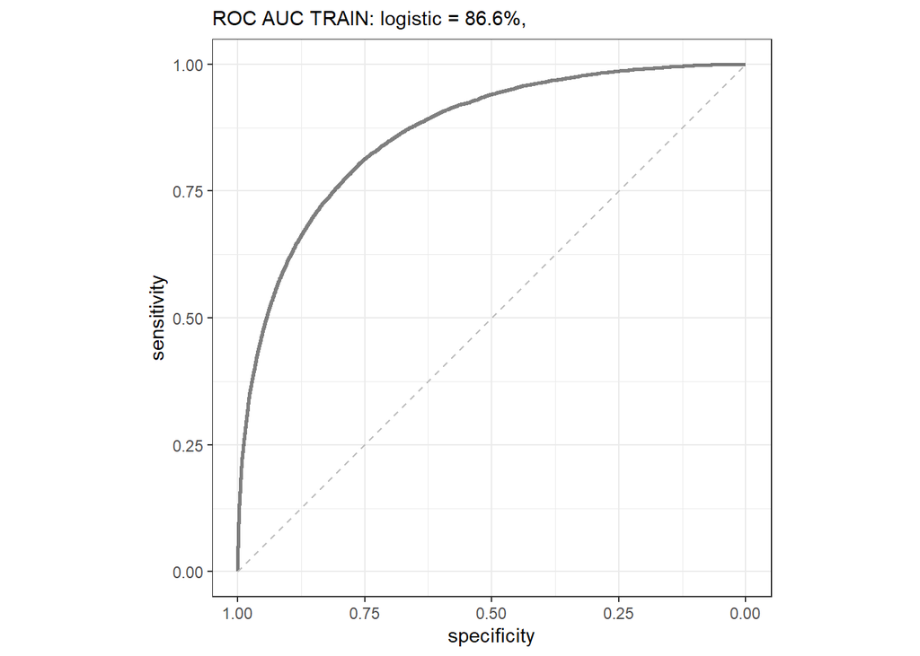

```r
pred.train.log <- predict(logistic,
                          data.train, type = "response")
ROC.train.log <- roc(data.train$RainTomorrow,
                        as.numeric(pred.train.log))

ROC.train.log %>%
pROC::ggroc(alpha = 0.5, linetype = 1, size = 1) +
geom_segment(aes(x = 1, xend = 0, y = 0, yend = 1),
              color = "grey",
              linetype = "dashed") +
labs(subtitle = paste0("ROC AUC TRAIN: ",
                        "logistic = ",
                        round(100 * auc(ROC.train.log) , 1), "%, ")) +
theme_bw() + coord_fixed()
```

We can also look at the confusion matrix.

```r
pred.train.log.class <- ifelse(pred.train.log > 0.5, 1, 0) # different cutoff?

confusionMatrix(data = as.factor(pred.train.log.class),
                reference = as.factor(data.train$RainTomorrow),
                positive = "1")
```

```
## Confusion Matrix and Statistics
##
##           Reference
## Prediction     0     1
##          0 73039 11209
##          1  4276 11012
##
##                Accuracy : 0.8444
##                  95% CI : (0.8422, 0.8467)
##     No Information Rate : 0.7768
##     P-Value [Acc > NIR] : < 2.2e-16
##
##                   Kappa : 0.4953
##
##  Mcnemar's Test P-Value : < 2.2e-16
##
##             Sensitivity : 0.4956
##             Specificity : 0.9447
##          Pos Pred Value : 0.7203
##          Neg Pred Value : 0.8670
##              Prevalence : 0.2232
##          Detection Rate : 0.1106
##    Detection Prevalence : 0.1536
##       Balanced Accuracy : 0.7201
##
##        'Positive' Class : 1
##
```

# 8 Decision Trees

We can create the first tree on the basis of all meaningful predictors. The default splitting criterion is the Gini Index.

```r
tree1 <-
  rpart(formula,
        data = data.train,
        method = "class")

saveRDS(object = tree1,
        file = here("output", "tree1.rds"))
```

Examine and plot the tree.

```r
tree1
```

```
## n= 99536
##
## node), split, n, loss, yval, (yprob)
##       * denotes terminal node
##
##  1) root 99536 22221 0 (0.7767541 0.2232459)
##    2) Humidity3pm< 0.705 81799 11589 0 (0.8583235 0.1416765) *
##    3) Humidity3pm>=0.705 17737  7105 1 (0.4005751 0.5994249)
##      6) Humidity3pm< 0.825 10273  4689 0 (0.5435608 0.4564392)
##       12) WindGustSpeed< 0.2790698 6312  2296 0 (0.6362484 0.3637516) *
##       13) WindGustSpeed>=0.2790698 3961  1568 1 (0.3958596 0.6041404) *
##      7) Humidity3pm>=0.825 7464  1521 1 (0.2037781 0.7962219) *
```

```r
summary(tree1)
```

```
## Call:
## rpart(formula = formula, data = data.train, method = "class")
##   n= 99536
##
##           CP nsplit rel error    xerror        xstd
## 1 0.15872373      0 1.0000000 1.0000000 0.005912348
## 2 0.04027722      1 0.8412763 0.8399712 0.005541875
## 3 0.03712704      2 0.8009991 0.8190450 0.005488118
## 4 0.01000000      3 0.7638720 0.7655821 0.005344587
##
## Variable importance
##   Humidity3pm      Cloud3pm      Sunshine       Temp3pm WindGustSpeed
##            73             6             5             5             3
##       MaxTemp   RainfallLog   Humidity9am  WindSpeed3pm  WindSpeed9am
##             3             1             1             1             1
##
## Node number 1: 99536 observations,    complexity param=0.1587237
##   predicted class=0  expected loss=0.2232459  P(node) =1
##     class counts: 77315 22221
##    probabilities: 0.777 0.223
##   left son=2 (81799 obs) right son=3 (17737 obs)
##   Primary splits:
##       Humidity3pm < 0.705      to the left,  improve=6108.458, (0 missing)
##       RainfallLog < 0.08452862 to the left,  improve=3292.074, (0 missing)
##       Sunshine    < 0.4172414  to the right, improve=2424.661, (0 missing)
##       Cloud3pm    < 7.5        to the left,  improve=2036.836, (0 missing)
##       Humidity9am < 0.7626263  to the left,  improve=1916.189, (0 missing)
##   Surrogate splits:
##       Cloud3pm    < 7.5        to the left,  agree=0.835, adj=0.075, (0 split)
##       Sunshine    < 0.07931034 to the right, agree=0.834, adj=0.069, (0 split)
##       Temp3pm     < 0.315739   to the right, agree=0.832, adj=0.059, (0 split)
##       MaxTemp     < 0.305293   to the right, agree=0.828, adj=0.032, (0 split)
##       RainfallLog < 0.5358741  to the left,  agree=0.825, adj=0.020, (0 split)
##
## Node number 2: 81799 observations
##   predicted class=0  expected loss=0.1416765  P(node) =0.8218032
##     class counts: 70210 11589
##    probabilities: 0.858 0.142
##
## Node number 3: 17737 observations,    complexity param=0.04027722
```

[output cut: 34 more lines]

```
##
## Node number 7: 7464 observations
##   predicted class=1  expected loss=0.2037781  P(node) =0.07498794
##     class counts:  1521  5943
##    probabilities: 0.204 0.796
##
## Node number 12: 6312 observations
##   predicted class=0  expected loss=0.3637516  P(node) =0.06341424
##     class counts:  4016  2296
##    probabilities: 0.636 0.364
##
## Node number 13: 3961 observations
##   predicted class=1  expected loss=0.3958596  P(node) =0.03979465
##     class counts:  1568  2393
##    probabilities: 0.396 0.604
```

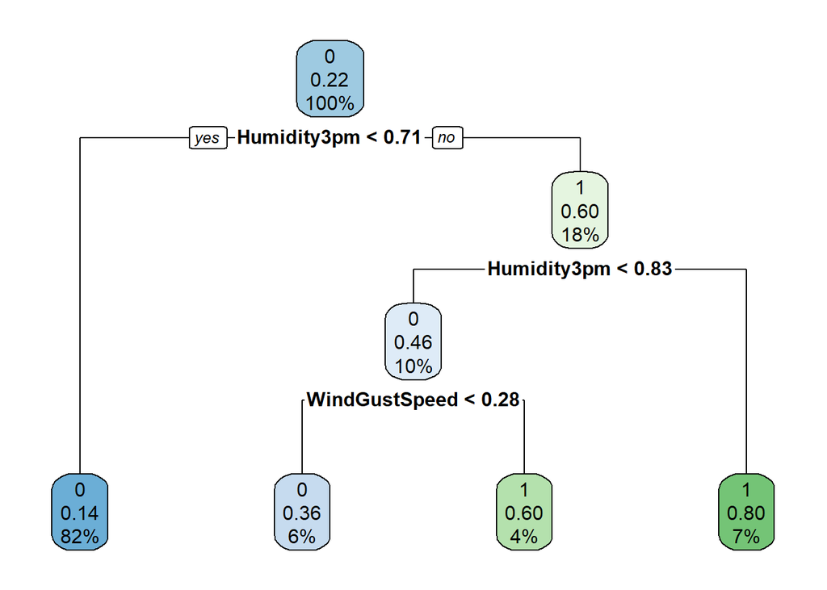

```r
rpart.plot(tree1)
```

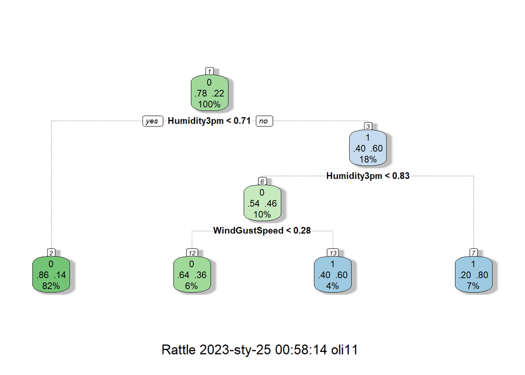

```r
fancyRpartPlot(tree1)
```

We can also try to build a tree based on the entropy and compare it with the tree based on the Gini Index.

```r
tree2 <-
  rpart(formula,
        data = data.train,
        method = "class",
        parms = list(split = 'information'))

saveRDS(object = tree2,
        file = here("output", "tree2.rds"))

tree2
```

```
## n= 99536
##
## node), split, n, loss, yval, (yprob)
##       * denotes terminal node
##
##  1) root 99536 22221 0 (0.7767541 0.2232459)
##    2) Humidity3pm< 0.665 76530  9797 0 (0.8719848 0.1280152) *
##    3) Humidity3pm>=0.665 23006 10582 1 (0.4599670 0.5400330)
##      6) Humidity3pm< 0.825 15542  6481 0 (0.5830009 0.4169991)
##       12) WindGustSpeed< 0.2790698 9769  3191 0 (0.6733545 0.3266455) *
##       13) WindGustSpeed>=0.2790698 5773  2483 1 (0.4301057 0.5698943)
##         26) RainfallLog< 0.03756494 2511  1124 0 (0.5523696 0.4476304) *
##         27) RainfallLog>=0.03756494 3262  1096 1 (0.3359902 0.6640098) *
##      7) Humidity3pm>=0.825 7464  1521 1 (0.2037781 0.7962219) *
```

```r
summary(tree2)
```

```
## Call:
## rpart(formula = formula, data = data.train, method = "class",
##     parms = list(split = "information"))
##   n= 99536
##
##           CP nsplit rel error    xerror        xstd
## 1 0.09950047      0 1.0000000 1.0000000 0.005912348
## 2 0.03631700      2 0.8009991 0.8006840 0.005439846
## 3 0.01183565      3 0.7646821 0.7648621 0.005342591
## 4 0.01000000      4 0.7528464 0.7528014 0.005308899
##
## Variable importance
##   Humidity3pm      Cloud3pm      Sunshine       Temp3pm   Humidity9am
##            67             7             6             5             5
##       MaxTemp WindGustSpeed  WindSpeed3pm  WindSpeed9am   RainfallLog
##             3             3             1             1             1
##
## Node number 1: 99536 observations,    complexity param=0.09950047
##   predicted class=0  expected loss=0.2232459  P(node) =1
##     class counts: 77315 22221
##    probabilities: 0.777 0.223
##   left son=2 (76530 obs) right son=3 (23006 obs)
##   Primary splits:
##       Humidity3pm < 0.665      to the left,  improve=7699.373, (0 missing)
##       RainfallLog < 0.06267534 to the left,  improve=4345.505, (0 missing)
##       Sunshine    < 0.6172414  to the right, improve=3141.614, (0 missing)
##       Humidity9am < 0.7323232  to the left,  improve=2727.110, (0 missing)
##       Cloud3pm    < 3.5        to the left,  improve=2468.810, (0 missing)
##   Surrogate splits:
##       Cloud3pm    < 7.5        to the left,  agree=0.795, adj=0.115, (0 split)
##       Sunshine    < 0.1344828  to the right, agree=0.790, adj=0.092, (0 split)
##       Humidity9am < 0.9141414  to the left,  agree=0.787, adj=0.080, (0 split)
##       Temp3pm     < 0.3349328  to the right, agree=0.787, adj=0.079, (0 split)
##       MaxTemp     < 0.3298677  to the right, agree=0.780, adj=0.048, (0 split)
##
## Node number 2: 76530 observations
##   predicted class=0  expected loss=0.1280152  P(node) =0.7688675
##     class counts: 66733  9797
##    probabilities: 0.872 0.128
##
```

[output cut: 58 more lines]

```
##       Humidity9am   < 0.7727273  to the left,  agree=0.665, adj=0.229, (0 split)
##       MaxTemp       < 0.5283554  to the right, agree=0.611, adj=0.105, (0 split)
##       Temp9am       < 0.5740343  to the right, agree=0.609, adj=0.100, (0 split)
##       Longitude     < 0.9379423  to the right, agree=0.606, adj=0.095, (0 split)
##       WindDir3pm_NE < 0.5        to the right, agree=0.604, adj=0.090, (0 split)
##
## Node number 26: 2511 observations
##   predicted class=0  expected loss=0.4476304  P(node) =0.02522705
##     class counts:  1387  1124
##    probabilities: 0.552 0.448
##
## Node number 27: 3262 observations
##   predicted class=1  expected loss=0.3359902  P(node) =0.03277206
##     class counts:  1096  2166
##    probabilities: 0.336 0.664
```

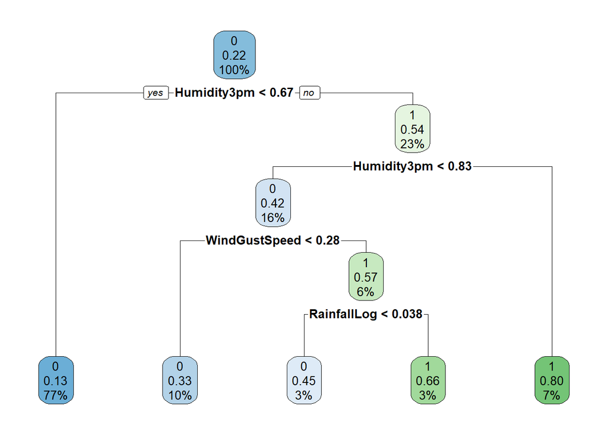

```r
rpart.plot(tree2)
```

[figure not shown]

```r
fancyRpartPlot(tree2)
```

We can try to build a tree with lower restrictions.

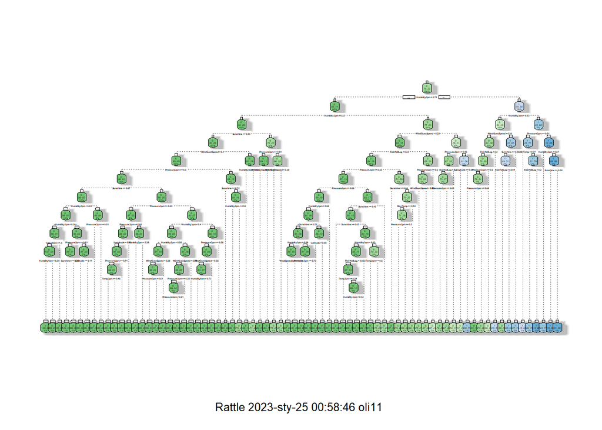

```r
tree3 <-
  rpart(formula,
        data = data.train,
        method = "class",
        minsplit = 2000, # ~ 2% of the training set
        minbucket = 1000, # ~ 1% of the training set
        maxdepth = 30, # default
        cp = -1)
fancyRpartPlot(tree3)
```

```r
saveRDS(object = tree3,
        file = here("output", "tree3.rds"))
```

Let’s find and save number of the `cp` row with the lowest error.

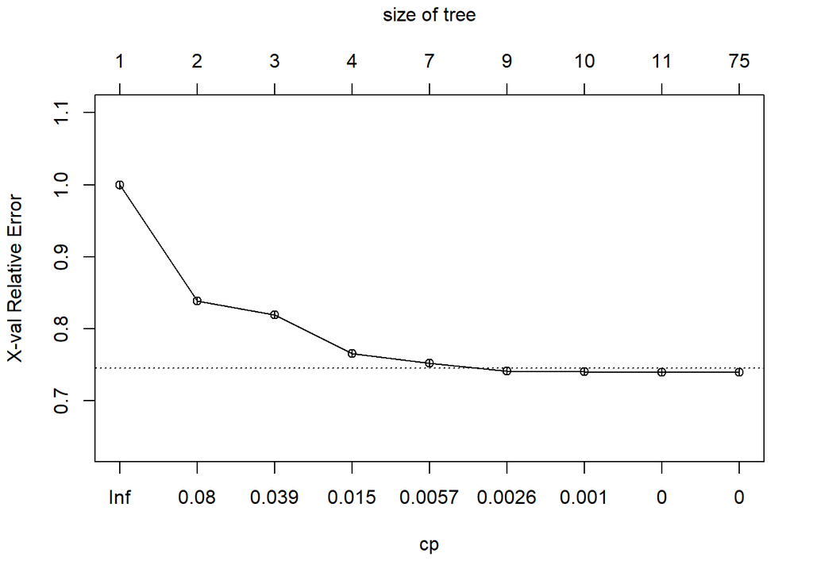

```r
opt <- which.min(tree3$cptable[, "xerror"])
cp <- tree3$cptable[opt, "CP"]
plotcp(tree3)
```

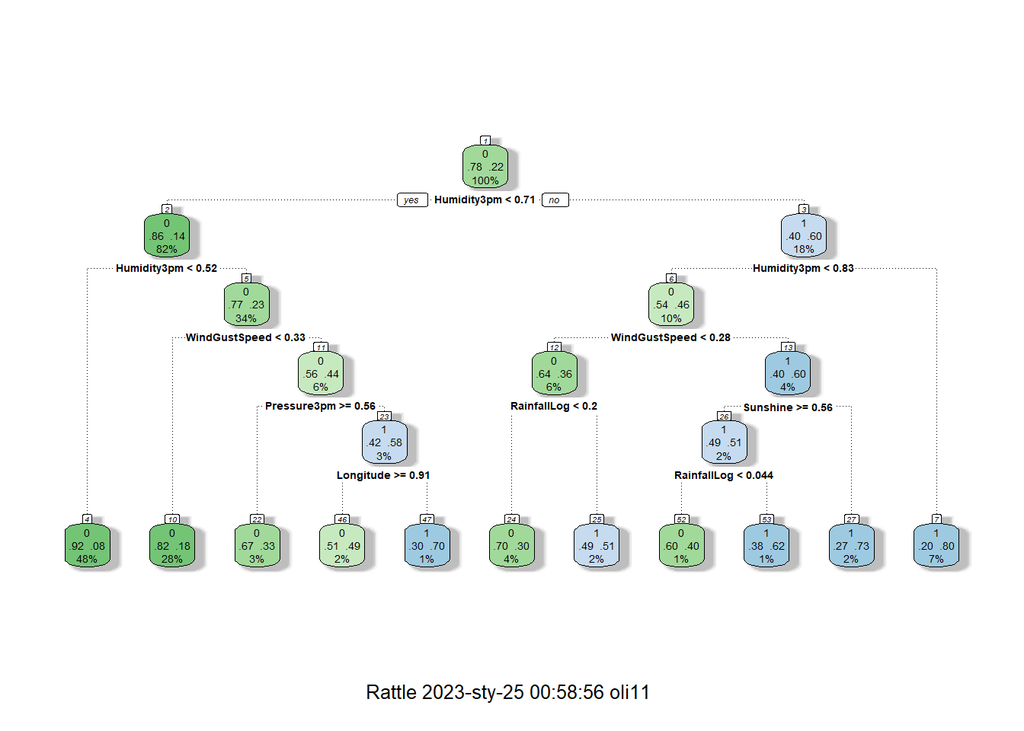

```r
tree3p <-
  prune(tree3, cp = cp)
fancyRpartPlot(tree3p)
```

```r
saveRDS(object = tree3p,
        file = here("output", "tree3p.rds"))
```

We can make a prediction based on the fitted trees and evaluate the errors.

```r
pred.train.tree1 <- predict(tree1, data.train)
pred.train.tree2 <- predict(tree2, data.train)
pred.train.tree3 <- predict(tree3, data.train)
pred.train.tree3p <- predict(tree3p, data.train)

ROC.train.tree1 <- roc(data.train$RainTomorrow == "1",
                        pred.train.tree1[, 2])
ROC.train.tree2 <- roc(data.train$RainTomorrow == "1",
                        pred.train.tree2[, 2])
ROC.train.tree3 <- roc(data.train$RainTomorrow == "1",
                        pred.train.tree3[, 2])
ROC.train.tree3p <- roc(data.train$RainTomorrow == "1",
                        pred.train.tree3p[, 2])
```

We can plot the ROC curves.

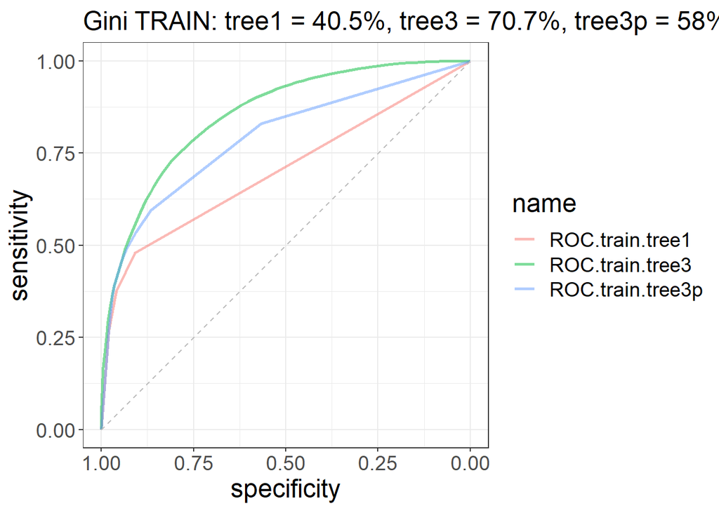

```r
list(
  ROC.train.tree1  = ROC.train.tree1,
  ROC.train.tree3  = ROC.train.tree3,
  ROC.train.tree3p = ROC.train.tree3p
) %>%
  ggroc(alpha = 0.5, linetype = 1, size = 1) +
  geom_segment(aes(x = 1, xend = 0, y = 0, yend = 1),
               color = "grey",
               linetype = "dashed") +
  labs(subtitle = paste0("Gini TRAIN: ",
                         "tree1 = ",
                         round(100*(2 * auc(ROC.train.tree1) - 1), 1), "%, ",
                         "tree3 = ",
                         round(100*(2 * auc(ROC.train.tree3) - 1), 1), "%, ",
                         "tree3p = ",
                         round(100*(2 * auc(ROC.train.tree3p) - 1), 1), "% ")) +
  theme_bw() + coord_fixed() + theme(text = element_text(size = 18))
```

We can also look at the confusion matrix.

```r
pred.train.tree3.class <- predict(tree3, data.train, type = "class")
confusionMatrix(data = pred.train.tree3.class,
                reference = as.factor(data.train$RainTomorrow),
                positive = "1")
```

```
## Confusion Matrix and Statistics
##
##           Reference
## Prediction     0     1
##          0 73659 12620
##          1  3656  9601
##
##                Accuracy : 0.8365
##                  95% CI : (0.8342, 0.8388)
##     No Information Rate : 0.7768
##     P-Value [Acc > NIR] : < 2.2e-16
##
##                   Kappa : 0.4494
##
##  Mcnemar's Test P-Value : < 2.2e-16
##
##             Sensitivity : 0.43207
##             Specificity : 0.95271
##          Pos Pred Value : 0.72422
##          Neg Pred Value : 0.85373
##              Prevalence : 0.22325
##          Detection Rate : 0.09646
##    Detection Prevalence : 0.13319
##       Balanced Accuracy : 0.69239
##
##        'Positive' Class : 1
##
```

```r
pred.train.tree3p.class <- predict(tree3p, data.train, type = "class")
confusionMatrix(data = pred.train.tree3p.class,
                reference = as.factor(data.train$RainTomorrow),
                positive = "1")
```

```
## Confusion Matrix and Statistics
##
##           Reference
## Prediction     0     1
##          0 73659 12620
##          1  3656  9601
##
##                Accuracy : 0.8365
##                  95% CI : (0.8342, 0.8388)
##     No Information Rate : 0.7768
##     P-Value [Acc > NIR] : < 2.2e-16
##
##                   Kappa : 0.4494
##
##  Mcnemar's Test P-Value : < 2.2e-16
##
##             Sensitivity : 0.43207
##             Specificity : 0.95271
##          Pos Pred Value : 0.72422
##          Neg Pred Value : 0.85373
##              Prevalence : 0.22325
##          Detection Rate : 0.09646
##    Detection Prevalence : 0.13319
##       Balanced Accuracy : 0.69239
##
##        'Positive' Class : 1
##
```

We can look at the importance of the variables.

```r
options(scipen = 100)
tree3.importance <- tree3$variable.importance
tree3.importance %>% sort(decreasing = TRUE)
```

```
##    Humidity3pm       Sunshine  WindGustSpeed        Temp3pm    Pressure3pm
## 8123.360784277 1173.892063127 1172.789796330  856.949236778  855.913081256
##    RainfallLog    Pressure9am        MaxTemp       Cloud3pm    Humidity9am
##  796.799563239  696.732558562  690.893228847  614.272370192  397.761951953
##   WindSpeed3pm        Temp9am        MinTemp   WindSpeed9am      Longitude
##  307.533130355  295.933880514  259.456642865  245.927262643   81.479193906
## EvaporationLog       Latitude       Cloud9am  Season_summer WindGustDir_SS
##   73.015341620   64.968499288   24.548179962    7.433691431    4.831602381
##   WindDir3pm_W  WindDir3pm_WN  WindDir9am_NN  WindDir9am_SW  WindDir3pm_SS
##    4.389197585    3.976096636    1.280533039    0.603767683    0.446032556
##  Season_winter  Season_autumm  WindDir9am_WN WindGustDir_WN
##    0.273567803    0.043980755    0.011098122    0.008719953
```

# 9 Random Forest

First, we need to transform target value to factors.

```r
data.train$RainTomorrow <- as.factor(data.train$RainTomorrow)
```

Now we can evaluate the Random Forest classifier.

```r
set.seed(123456789)
random.forest1 <- randomForest(as.formula(formula),
                              data = data.train)

saveRDS(object = random.forest1,
        file = here("output", "random.forest1.rds"))
```

We can examine the results and create a plot.

```r
print(random.forest1)
```

```
##
## Call:
##  randomForest(formula = as.formula(formula), data = data.train)
##                Type of random forest: classification
##                      Number of trees: 500
## No. of variables tried at each split: 8
##
##         OOB estimate of  error rate: 14.25%
## Confusion matrix:
##       0     1 class.error
## 0 74030  3285  0.04248852
## 1 10895 11326  0.49030197
```

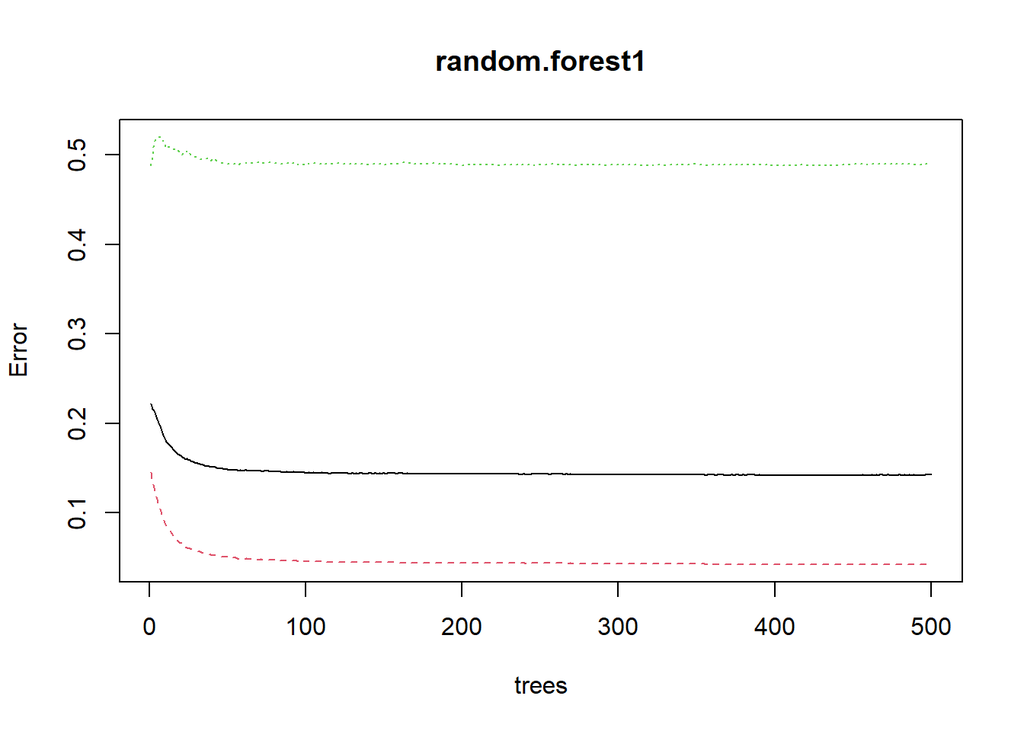

```r
plot(random.forest1)
```

We can experiment with setting different number of trees or using more variables.

```r
random.forest2 <-
  randomForest(as.formula(formula),
               data = data.train,
               ntree = 300,
               sampsize = nrow(data.train),
               mtry = 8,
               # minimum number of obs in the terminal nodes
               nodesize = 100,
               # we also generate predictors importance measures
               importance = TRUE)
print(random.forest2)
```

```
##
## Call:
##  randomForest(formula = as.formula(formula), data = data.train,      ntree = 300, sampsize = nrow(data.train), mtry = 8, nodesize = 100,      importance = TRUE)
##                Type of random forest: classification
##                      Number of trees: 300
## No. of variables tried at each split: 8
##
##         OOB estimate of  error rate: 14.87%
## Confusion matrix:
##       0     1 class.error
## 0 74219  3096  0.04004398
## 1 11707 10514  0.52684398
```

```r
saveRDS(object = random.forest2,
        file = here("output", "random.forest2.rds"))
```

Let’s find the best value of the number of variables (*mtry*) using cross validation. As it is very time consuming it was performed once and the results were saved in the *.rds* file.

```r
if(0){
  set.seed(123456789)

  parameters_rf <- expand.grid(mtry = 2:30)
  ctrl_cv <- trainControl(method = "cv",
                        number = 5,
                        classProbs = TRUE)

  # we need to change the level names of the target variable as 0 and 1 produce error in the train function
  data.train2 <- data.train %>%
     mutate(RainTomorrow = factor(RainTomorrow,
                                  labels = c("No", "Yes")))

  random.forest3 <-
  train(as.formula(formula),
        data = data.train2,
        method = "rf",
        ntree = 100,
        nodesize = 100,
        tuneGrid = parameters_rf,
        trControl = ctrl_cv,
        importance = TRUE)

  saveRDS(object = random.forest3,
        file = here("output", "random.forest3.rds"))
} # very time consuming!

random.forest3 <- readRDS(file = here("output", "random.forest3.rds"))
```

Let’s look at the plot.

```r
random.forest3
```

```
## Random Forest
##
## 99536 samples
##    64 predictor
##     2 classes: 'X0', 'X1'
##
## No pre-processing
## Resampling: Cross-Validated (5 fold)
## Summary of sample sizes: 79629, 79629, 79628, 79629, 79629
## Resampling results across tuning parameters:
##
##   mtry  Accuracy   Kappa
##    2    0.8304533  0.3619600
##    3    0.8430618  0.4447895
##    4    0.8479244  0.4759902
```

[output cut: 29 more lines]

```r
str(random.forest3)
```

[output not shown]

[output cut: 334 more lines]

[output not shown]

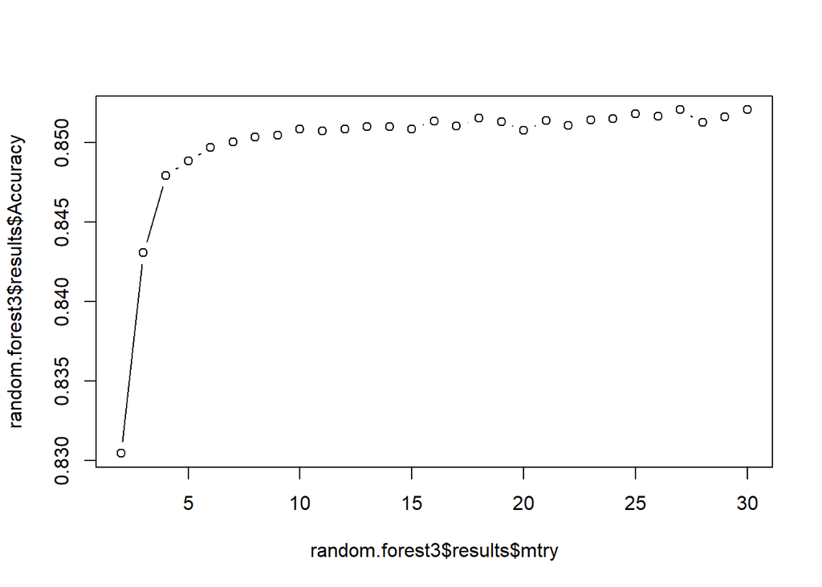

```r
plot(random.forest3$results$mtry,
     random.forest3$results$Accuracy, type = "b")
```

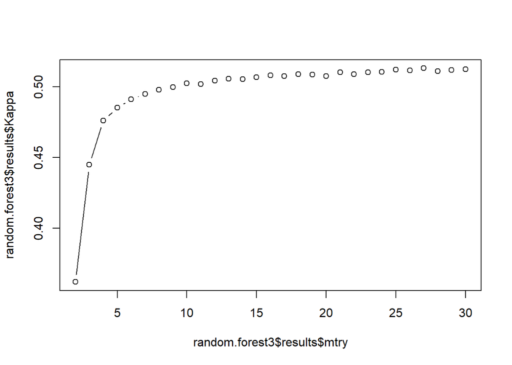

```r
plot(random.forest3$results$mtry,
     random.forest3$results$Kappa, type = "b")
```

```r
# Model with mtry = 12
random.forest4 <-
  randomForest(as.formula(formula),
               data = data.train,
               ntree = 300,
               sampsize = nrow(data.train),
               mtry = 12,
               nodesize = 100,
               importance = TRUE)

saveRDS(object = random.forest4,
      file = here("output", "random.forest4.rds"))
```

Let’s plot the ROC curves.

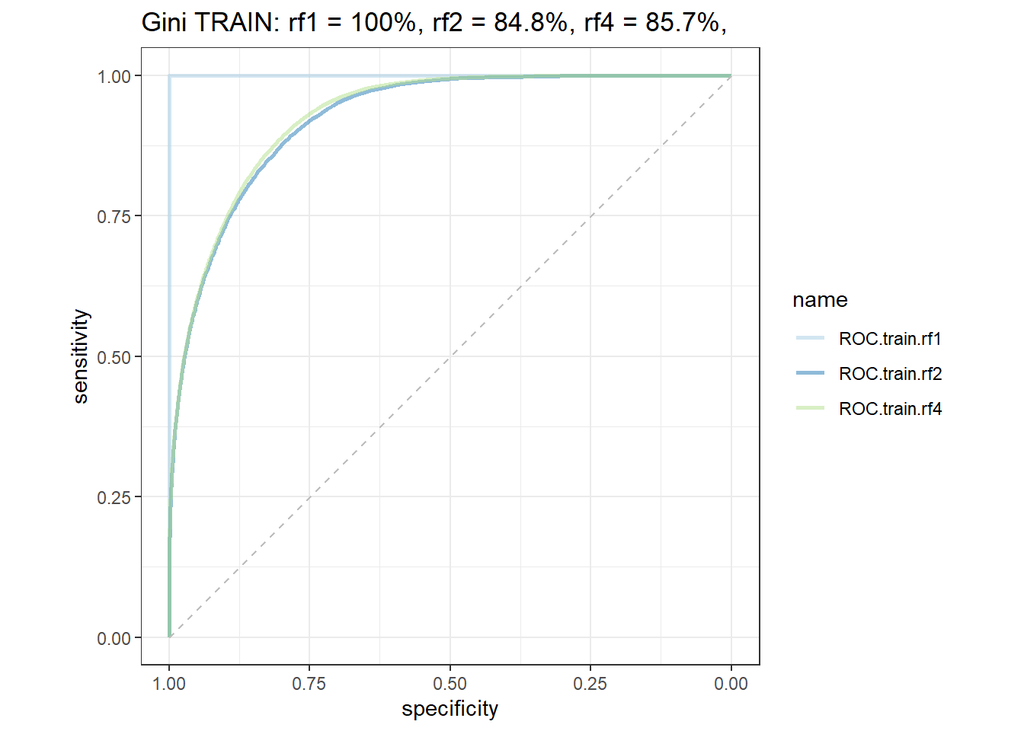

```r
pred.train.rf1 <- predict(random.forest1,
                         data.train,
                         type = "prob")[, "1"]
pred.train.rf2 <- predict(random.forest2,
                         data.train,
                         type = "prob")[, "1"]
pred.train.rf4 <- predict(random.forest4,
                         data.train,
                         type = "prob")[, "1"]

ROC.train.rf1  <- roc(data.train$RainTomorrow == "1",
                      pred.train.rf1)
ROC.train.rf2  <- roc(data.train$RainTomorrow == "1",
                      pred.train.rf2)
ROC.train.rf4  <- roc(data.train$RainTomorrow == "1",
                      pred.train.rf4)

list(
  ROC.train.rf1 = ROC.train.rf1,
  ROC.train.rf2 = ROC.train.rf2,
  ROC.train.rf4 = ROC.train.rf4
) %>%
  pROC::ggroc(alpha = 0.5, linetype = 1, size = 1) +
  geom_segment(aes(x = 1, xend = 0, y = 0, yend = 1),
               color = "grey",
               linetype = "dashed") +
  labs(title = paste0("Gini TRAIN: ",
                      "rf1 = ",
                      round(100 * (2 * auc(ROC.train.rf1) - 1), 1), "%, ",
                      "rf2 = ",
                      round(100 * (2 * auc(ROC.train.rf2) - 1), 1), "%, ",
                      "rf4 = ",
                      round(100 * (2 * auc(ROC.train.rf4) - 1), 1), "%, ")) +
  theme_bw() + coord_fixed() +
  scale_color_brewer(palette = "Paired")
```

We can analyze the variables importance.

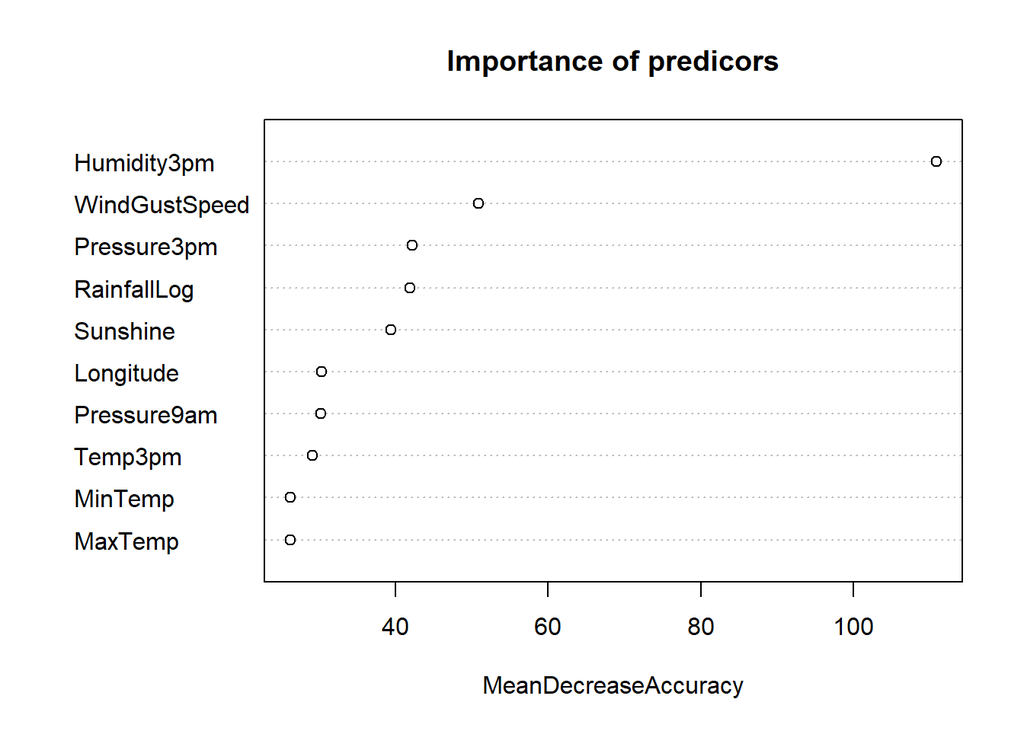

```r
varImpPlot(random.forest3$finalModel,
           sort = TRUE,
           main = "Importance of predicors",
           n.var = 10,
           type = 1) # mean decrease in accuracy
```

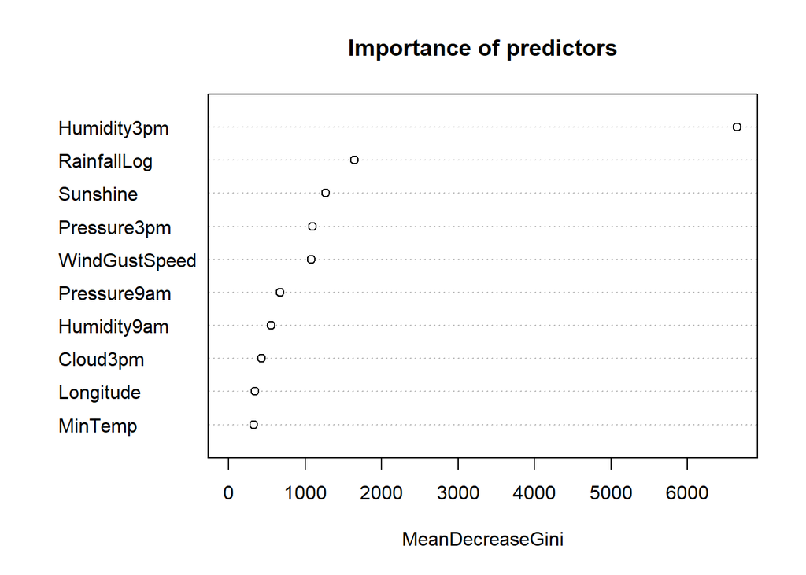

```r
varImpPlot(random.forest3$finalModel,
           sort = TRUE,
           main = "Importance of predictors",
           n.var = 10,
           type = 2) # mean decrease in node impurity
```

# 10 Gradient Boosting

Let’s create the first gradient boosting model with arbitrarly chosen parameters.

```r
# gbm does not work with a factor variables
data.train$RainTomorrow <- as.character(data.train$RainTomorrow)

start <- Sys.time()
gbm1 <-
  gbm(as.formula(formula),
      data = data.train,
      distribution = "bernoulli",
      # total number of trees
      n.trees = 500,
      # number of variable interactions - actually depth of the trees
      interaction.depth = 4,
      # shrinkage parameter - speed (pace) of learning
      shrinkage = 0.01,
      verbose = FALSE)
end <- Sys.time()
print(end - start)
```

```
## Time difference of 2.967887 mins
```

```r
gbm1 %>% saveRDS(here("output", "gbm1.rds"))
```

We can perform the parameters tuning (should take around 40min, so it was performed once and results were saved).

```r
modelLookup("gbm")
```

```
##   model         parameter                   label forReg forClass probModel
## 1   gbm           n.trees   # Boosting Iterations   TRUE     TRUE      TRUE
## 2   gbm interaction.depth          Max Tree Depth   TRUE     TRUE      TRUE
## 3   gbm         shrinkage               Shrinkage   TRUE     TRUE      TRUE
## 4   gbm    n.minobsinnode Min. Terminal Node Size   TRUE     TRUE      TRUE
```

```r
parameters_gbm <- expand.grid(interaction.depth = c(2, 4),
                             n.trees = c(200, 500),
                             shrinkage = c(0.01, 0.1),
                             n.minobsinnode = c(200, 500))
ctrl_cv3 <- trainControl(method = "cv",
                         number = 3,
                         classProbs = TRUE,
                         summaryFunction = twoClassSummary)

if (0) {
  set.seed(123456789)

  # we need to change the level names of the target variable as 0 and 1 produce error in the train function
  data.train2 <- data.train %>%
     mutate(RainTomorrow = factor(RainTomorrow,
                                  labels = c("No", "Yes")))

  gbm2  <- train(as.formula(formula),
                 data = data.train2,
                 distribution = "bernoulli",
                 method = "gbm",
                 tuneGrid = parameters_gbm,
                 trControl = ctrl_cv3,
                 verbose = FALSE)

  saveRDS(object = gbm2,
          file = here("output", "gbm2.rds"))
}

gbm2 <- readRDS(here("output", "gbm2.rds"))
gbm2
```

```
## Stochastic Gradient Boosting
##
## 99536 samples
##    64 predictor
##     2 classes: 'No', 'Yes'
##
## No pre-processing
## Resampling: Cross-Validated (3 fold)
## Summary of sample sizes: 66358, 66357, 66357
## Resampling results across tuning parameters:
##
##   shrinkage  interaction.depth  n.minobsinnode  n.trees  ROC        Sens
##   0.01       2                  200             200      0.8397926  0.9728772
##   0.01       2                  200             500      0.8566020  0.9576020
##   0.01       2                  500             200      0.8398742  0.9734851
##   0.01       2                  500             500      0.8566728  0.9576279
##   0.01       4                  200             200      0.8504564  0.9671603
##   0.01       4                  200             500      0.8632383  0.9512255
##   0.01       4                  500             200      0.8500865  0.9672250
##   0.01       4                  500             500      0.8631981  0.9512643
##   0.10       2                  200             200      0.8699136  0.9496346
##   0.10       2                  200             500      0.8773699  0.9490526
##   0.10       2                  500             200      0.8698671  0.9495570
##   0.10       2                  500             500      0.8772891  0.9487292
##   0.10       4                  200             200      0.8768663  0.9474229
##   0.10       4                  200             500      0.8848421  0.9486128
##   0.10       4                  500             200      0.8771043  0.9474099
##   0.10       4                  500             500      0.8847921  0.9487292
##   Spec
##   0.3480941
##   0.4390891
##   0.3468341
##   0.4397642
##   0.3870663
##   0.4750011
##   0.3853112
##   0.4759012
##   0.4917870
##   0.5139733
##   0.4947572
##   0.5133432
##   0.5189235
##   0.5357095
##   0.5189685
##   0.5335493
##
## ROC was used to select the optimal model using the largest value.
## The final values used for the model were n.trees = 500, interaction.depth =
##  4, shrinkage = 0.1 and n.minobsinnode = 200.
```

Let’s look at the ROC on the train dataset for both models.

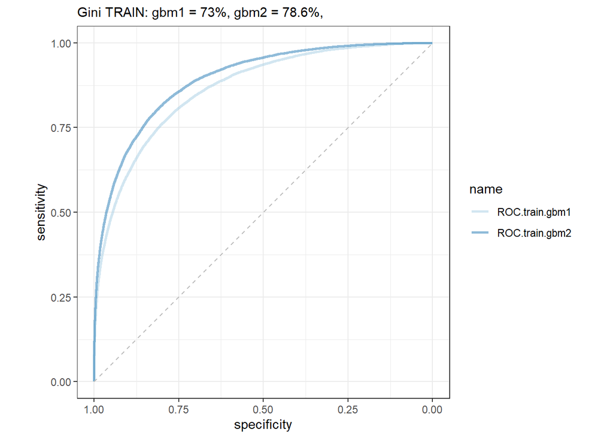

```r
pred.train.gbm1 <- predict(gbm1,
                           data.train,
                           type = "response",
                           ntrees = 500)
pred.train.gbm2 <- predict(gbm2,
                           data.train,
                           type = "prob",
                           ntrees = 500)[, "Yes"]

ROC.train.gbm1  <- roc(data.train$RainTomorrow == "1",
                       pred.train.gbm1)
ROC.train.gbm2  <- roc(data.train$RainTomorrow == "1",
                       pred.train.gbm2)

list(
  ROC.train.gbm1 = ROC.train.gbm1,
  ROC.train.gbm2 = ROC.train.gbm2
) %>%
  pROC::ggroc(alpha = 0.5, linetype = 1, size = 1) +
  geom_segment(aes(x = 1, xend = 0, y = 0, yend = 1),
               color = "grey",
               linetype = "dashed") +
  labs(subtitle = paste0("Gini TRAIN: ",
                         "gbm1 = ",
                         round(100 * (2 * auc(ROC.train.gbm1) - 1), 1), "%, ",
                         "gbm2 = ",
                         round(100 * (2 * auc(ROC.train.gbm2) - 1), 1), "%, "
  )) +
  theme_bw() + coord_fixed() +
  scale_color_brewer(palette = "Paired")
```

# 11 Comparison of models

We can plot ROC curves on the test data set.

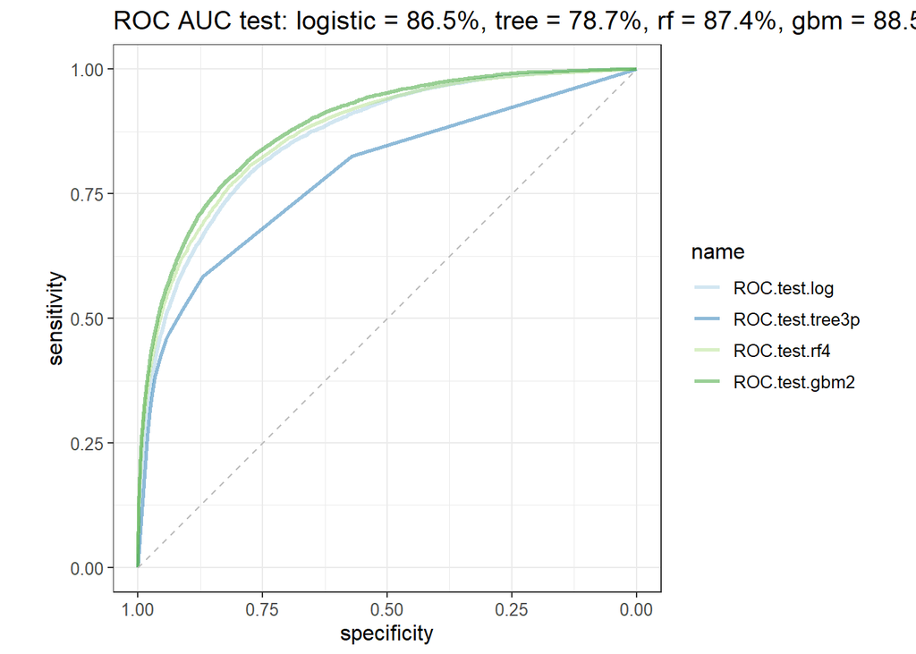

```r
pred.test.log <- predict(logistic,
                         data.test,
                         type = "response")
pred.test.tree3p <- predict(tree3p,
                            data.test)
pred.test.rf4 <- predict(random.forest4,
                         data.test,
                         type = "prob")[, "1"]
pred.test.gbm2 <- predict(gbm2,
                          data.test,
                          type = "prob",
                          ntrees = 500)[, "Yes"]

ROC.test.log <- roc(data.test$RainTomorrow,
                        as.numeric(pred.test.log))
ROC.test.tree3p <- roc(data.test$RainTomorrow == "1",
                        pred.test.tree3p[, 2])
ROC.test.rf4  <- roc(data.test$RainTomorrow == "1",
                      pred.test.rf4)
ROC.test.gbm2  <- roc(data.test$RainTomorrow == "1",
                       pred.test.gbm2)

list(
  ROC.test.log = ROC.test.log,
  ROC.test.tree3p = ROC.test.tree3p,
  ROC.test.rf4 = ROC.test.rf4,
  ROC.test.gbm2 = ROC.test.gbm2
) %>%
  pROC::ggroc(alpha = 0.5, linetype = 1, size = 1) +
  geom_segment(aes(x = 1, xend = 0, y = 0, yend = 1),
               color = "grey",
               linetype = "dashed") +
  labs(title = paste0("ROC AUC test: ",
                      "logistic = ",
                      round(100 * auc(ROC.test.log) , 1), "%, ",
                      "tree = ",
                      round(100 * auc(ROC.test.tree3p) , 1), "%, ",
                      "rf = ",
                      round(100 * auc(ROC.test.rf4) , 1), "%, ",
                      "gbm = ",
                      round(100 * auc(ROC.test.gbm2) , 1), "%, ")) +
  theme_bw() + coord_fixed() +
  scale_color_brewer(palette = "Paired") + theme(text = element_text(size = 12))
```

Confusion matrix for the best model.

```r
pred.test.gbm2.class <- predict(gbm2, data.test, type = "raw")
confusionMatrix(data = pred.test.gbm2.class,
                reference = factor(data.test$RainTomorrow, labels = c("No", "Yes")),
                positive = "Yes")
```

```
## Confusion Matrix and Statistics
##
##           Reference
## Prediction    No   Yes
##        No  31433  4515
##        Yes  1568  5141
##
##                Accuracy : 0.8574
##                  95% CI : (0.854, 0.8607)
##     No Information Rate : 0.7736
##     P-Value [Acc > NIR] : < 2.2e-16
##
##                   Kappa : 0.5436
##
##  Mcnemar's Test P-Value : < 2.2e-16
##
##             Sensitivity : 0.5324
##             Specificity : 0.9525
##          Pos Pred Value : 0.7663
##          Neg Pred Value : 0.8744
##              Prevalence : 0.2264
##          Detection Rate : 0.1205
##    Detection Prevalence : 0.1573
##       Balanced Accuracy : 0.7425
##
##        'Positive' Class : Yes
##
```

# 12 Ensembling

We can try to mix the models in order to obtain even better fit.

```r
models <- c("logistic", "rf4", "gbm2")
preds.train <- data.frame("logistic" = pred.train.log, "rf4" = pred.train.rf4, "gbm2" = pred.train.gbm2)

cor(preds.train)
```

```
##           logistic       rf4      gbm2
## logistic 1.0000000 0.9200728 0.9453555
## rf4      0.9200728 1.0000000 0.9549345
## gbm2     0.9453555 0.9549345 1.0000000
```

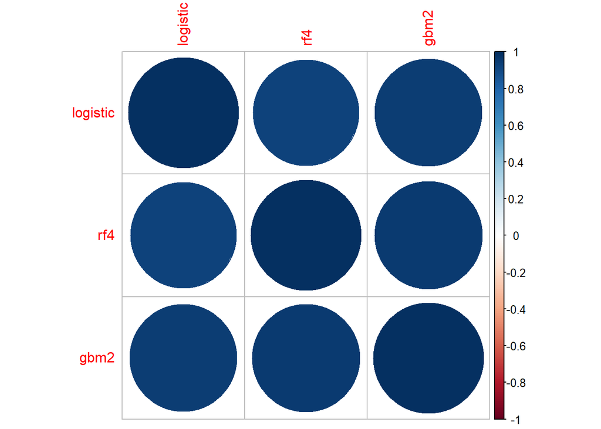

```r
corrplot::corrplot(cor(preds.train))
```

Correlations are quite high, but still we can try to ensemble and compare results. We can try majority voting.

```r
preds.train$major.voting <-
  ifelse(rowSums(preds.train[, models] > 0.5) > 1,
         1,
         0)
```

And also simple averaging.

```r
preds.train$simple.averaging <-
  ifelse(rowMeans(preds.train[, models]) > 0.5,
         1,
         0)
```

Let’s plot the ensemble models on the train data set.

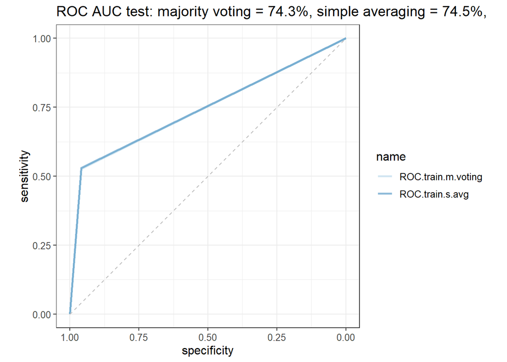

```r
ROC.train.m.voting <- roc(data.train$RainTomorrow,
                          preds.train$major.voting)
ROC.train.s.avg <- roc(data.train$RainTomorrow,
                      preds.train$simple.averaging)

list(
  ROC.train.m.voting = ROC.train.m.voting,
  ROC.train.s.avg = ROC.train.s.avg
) %>%
  pROC::ggroc(alpha = 0.5, linetype = 1, size = 1) +
  geom_segment(aes(x = 1, xend = 0, y = 0, yend = 1),
               color = "grey",
               linetype = "dashed") +
  labs(title = paste0("ROC AUC test: ",
                      "majority voting = ",
                      round(100 * auc(ROC.train.m.voting) , 1), "%, ",
                      "simple averaging = ",
                      round(100 * auc(ROC.train.s.avg) , 1), "%, ")) +
  theme_bw() + coord_fixed() +
  scale_color_brewer(palette = "Paired") + theme(text = element_text(size = 12))
```

And on the test data set.

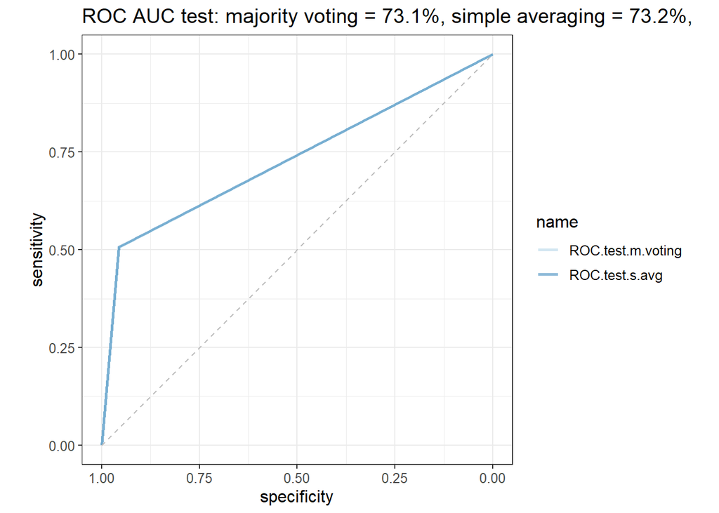

```r
preds.test <- data.frame("logistic" = pred.test.log, "rf4" = pred.test.rf4, "gbm2" = pred.test.gbm2)

preds.test$major.voting <-
  ifelse(rowSums(preds.test[, models] > 0.5) > 1,
         1,
         0)

preds.test$simple.averaging <-
  ifelse(rowMeans(preds.test[, models]) > 0.5,
         1,
         0)

ROC.test.m.voting <- roc(data.test$RainTomorrow,
                          preds.test$major.voting)
ROC.test.s.avg <- roc(data.test$RainTomorrow,
                      preds.test$simple.averaging)

list(
  ROC.test.m.voting = ROC.test.m.voting,
  ROC.test.s.avg = ROC.test.s.avg
) %>%
  pROC::ggroc(alpha = 0.5, linetype = 1, size = 1) +
  geom_segment(aes(x = 1, xend = 0, y = 0, yend = 1),
               color = "grey",
               linetype = "dashed") +
  labs(title = paste0("ROC AUC test: ",
                      "majority voting = ",
                      round(100 * auc(ROC.test.m.voting) , 1), "%, ",
                      "simple averaging = ",
                      round(100 * auc(ROC.test.s.avg) , 1), "%, ")) +
  theme_bw() + coord_fixed() +
  scale_color_brewer(palette = "Paired") + theme(text = element_text(size = 12))
```

Ensembling did not improve the performance. Overall, the best model is gradient boosting with the ROC AUC score equal to 88.5